# HW04

沈毓麟 / B02201057 / 數學四

2017年5月13日

讀取資料: 使用套件readxl可以直接讀取excel檔案，而讀取用的檔案分別是每一年每天的溫度檔案及不同大樓的用電量檔案資料，另外這邊也針對每一棟不同的大樓給出一些基本統計量，目前訂定為rawdata。

```r
ele <- readxl::read_excel("2016ele.xlsx")
temp <- readxl::read_excel("2016temp.xlsx")
ele$溫度 <- temp$AVG_of_T
rawdata <- ele

# 看資料基本統計
summary(rawdata)
```

```
##    日期/館舍                       數學館      新數學研究中心
##  Min.   :2016-01-01 00:00:00   Min.   :227.5   Min.   :109.4
##  1st Qu.:2016-04-01 06:00:00   1st Qu.:429.1   1st Qu.:193.1
##  Median :2016-07-01 12:00:00   Median :551.5   Median :225.4
##  Mean   :2016-07-01 12:00:00   Mean   :575.6   Mean   :265.4
##  3rd Qu.:2016-09-30 18:00:00   3rd Qu.:727.8   3rd Qu.:356.2
##  Max.   :2016-12-31 00:00:00   Max.   :956.3   Max.   :589.5
##    -新生大樓-         生化所        電機一館        化學館
##  Min.   : 167.2   Min.   :1430   Min.   :1498   Min.   : 7121
##  1st Qu.: 389.8   1st Qu.:2137   1st Qu.:3058   1st Qu.: 9517
##  Median : 858.4   Median :2529   Median :3370   Median :10856
##  Mean   : 933.0   Mean   :2587   Mean   :3320   Mean   :10934
##  3rd Qu.:1263.1   3rd Qu.:3034   3rd Qu.:3633   3rd Qu.:12440
##  Max.   :2337.4   Max.   :4104   Max.   :4147   Max.   :15086
##      積學館          思亮館        -原分所-     凝態物理科學館
##  Min.   : 4205   Min.   :1177   Min.   : 7614   Min.   :12604
##  1st Qu.: 6407   1st Qu.:1696   1st Qu.:10930   1st Qu.:17466
##  Median : 7431   Median :2097   Median :11973   Median :19212
##  Mean   : 7729   Mean   :2065   Mean   :12008   Mean   :19134
##  3rd Qu.: 9234   3rd Qu.:2365   3rd Qu.:13273   3rd Qu.:20969
##  Max.   :11107   Max.   :3335   Max.   :14743   Max.   :24238
##  物理學系/凝態中心停車場 心理南研究大樓    心理系北館     應用力學研究大樓
##  Min.   : 35.60          Min.   :126.9   Min.   : 512.9   Min.   :1856
##  1st Qu.: 96.37          1st Qu.:210.0   1st Qu.:1097.1   1st Qu.:3525
##  Median : 99.27          Median :271.1   Median :1775.3   Median :4197
##  Mean   :100.18          Mean   :309.7   Mean   :1597.6   Mean   :4370
##  3rd Qu.:109.67          3rd Qu.:411.8   3rd Qu.:2101.9   3rd Qu.:5304
##  Max.   :122.53          Max.   :711.6   Max.   :2571.2   Max.   :6856
##  工學院綜合大樓       溫度
##  Min.   : 4585   Min.   : 4.562
##  1st Qu.: 7826   1st Qu.:18.548
##  Median : 9176   Median :23.959
##  Mean   : 9635   Mean   :22.624
##  3rd Qu.:11824   3rd Qu.:27.236
##  Max.   :15127   Max.   :30.983
```

```r
rawdata <- as.data.frame(rawdata)
# 觀看資料型態
knitr::kable(head(rawdata))
```

| 日期/館舍 | 數學館 | 新數學研究中心 | -新生大樓- | 生化所 | 電機一館 | 化學館 | 積學館 | 思亮館 | -原分所- | 凝態物理科學館 | 物理學系/凝態中心停車場 | 心理南研究大樓 | 心理系北館 | 應用力學研究大樓 | 工學院綜合大樓 | 溫度 |
| --- | --- | --- | --- | --- | --- | --- | --- | --- | --- | --- | --- | --- | --- | --- | --- | --- |
| 2016-01-01 | 349.54 | 154.18 | 340.28 | 1714.87 | 3009.06 | 9075.20 | 5249.11 | 1391.35 | 9745.25 | 16229.16 | 104.80 | 169.63 | 1118.18 | 3249.91 | 6208.62 | 18.14809 |
| 2016-01-02 | 324.94 | 147.66 | 255.09 | 1733.56 | 3076.44 | 9231.44 | 5285.32 | 1375.63 | 10055.27 | 16356.06 | 104.67 | 165.37 | 1135.07 | 3292.34 | 6346.88 | 17.82778 |
| 2016-01-03 | 363.59 | 136.09 | 260.34 | 1765.38 | 3200.75 | 9221.72 | 5415.57 | 1352.66 | 9975.26 | 16409.23 | 104.56 | 170.38 | 1172.18 | 3258.42 | 6527.68 | 18.18131 |
| 2016-01-04 | 414.44 | 209.41 | 777.19 | 2125.31 | 3424.25 | 10290.72 | 6340.81 | 1786.72 | 11630.35 | 18176.79 | 105.14 | 250.37 | 1340.13 | 3775.28 | 8229.63 | 19.44624 |
| 2016-01-05 | 482.68 | 215.68 | 783.53 | 2217.75 | 3633.37 | 10632.07 | 6685.21 | 1932.86 | 12048.17 | 18722.77 | 104.83 | 286.31 | 1571.00 | 3832.23 | 8533.62 | 19.75250 |
| 2016-01-06 | 451.85 | 203.24 | 919.85 | 2200.06 | 3471.75 | 10227.51 | 6600.68 | 1854.55 | 11567.15 | 18365.26 | 104.44 | 256.63 | 1438.62 | 3766.73 | 8374.13 | 17.84163 |

每日的用電量漲幅以及溫度的變化

```r
diff <- rawdata[2:length(rawdata$數學館),] - rawdata[1:length(rawdata$數學館)-1,]
diff <- diff[,-1]
rhodiff <- cor(diff)
```

修正欄位名稱

```r
bunames <- colnames(rawdata)
bunames[4] <- c("新生大樓")
bunames[10] <- c("原分所")
bunames[12] <- c("物理學系凝態中心停車場")
```

資料格式轉換: 將原本以欄位為不同大樓資料的rawdata轉變成圖片比較適合的格式，目前訂定為rawdata1。

```r
# 2016用電量分布圖
require(ggplot2)
old <- theme_set(theme_bw())
rawdata1 <- as.data.frame(matrix(nrow=dim(rawdata)[1]*15, ncol = 3))
rawdata1[,1] <- rep(rawdata[,1], 15)
rawdata1[,2] <- rep(rawdata[,17], 15)
fir <- dim(rawdata)[1]*(0:14)+1
las <- dim(rawdata)[1]*(1:15)
for(i in 1:15) {
  rawdata1[fir[i]:las[i],3] <- rep(bunames[i+1],366)
  rawdata1[fir[i]:las[i],4] <- rawdata[,i+1]
}
colnames(rawdata1) <- c("date", "temp", "building", "ele")
# 觀看資料型態
knitr::kable(head(rawdata1))
```

| date | temp | building | ele |
| --- | --- | --- | --- |
| 2016-01-01 | 18.14809 | 數學館 | 349.54 |
| 2016-01-02 | 17.82778 | 數學館 | 324.94 |
| 2016-01-03 | 18.18131 | 數學館 | 363.59 |
| 2016-01-04 | 19.44624 | 數學館 | 414.44 |
| 2016-01-05 | 19.75250 | 數學館 | 482.68 |
| 2016-01-06 | 17.84163 | 數學館 | 451.85 |

不同大樓用電量的分布趨勢

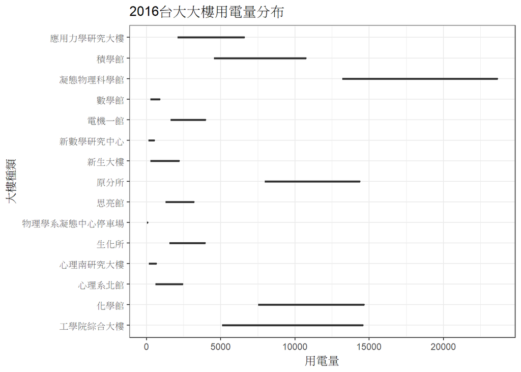

```r
ggplot(data = rawdata1, aes(x = ele , y = building)) +
  geom_boxplot()+
  labs( y = '大樓種類', x = '用電量',
        title = '2016台大大樓用電量分布')
```

不同大樓下的用電量平均數的點散布圖

```r
library(Hmisc)
```

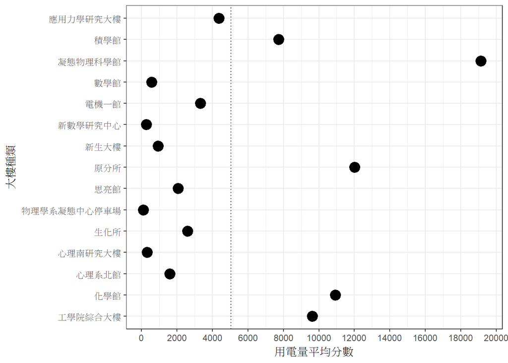

```r
ggplot(data = rawdata1,
       aes(x = building, y = ele)) +
  stat_summary(fun.data = 'mean_cl_boot', size = 1) +
  scale_y_continuous(breaks = seq(0, 20000, by = 2000)) +
  geom_hline(yintercept = mean(rawdata1$ele) ,
             linetype = 'dotted') +
  labs(x = '大樓種類', y = '用電量平均分數') +
  coord_flip()
```

查看不同大樓中用電量可能會有的機率密度

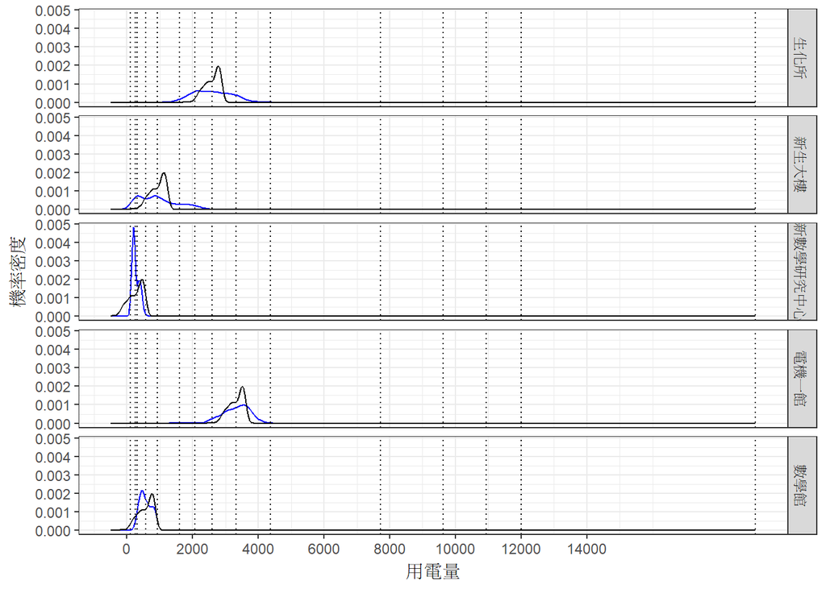

```r
# 各大樓用電量出現不同數值發生的機率密度

#畫效果
require(coefplot)
rd1 <- rawdata1[1:1830,]
rd2 <- rawdata1[1831:3660,]
rd3 <- rawdata1[-c(1:3660),]
#將截距去除，畫更易懂起來
m1 <- lm(ele ~ building+temp-1,
         data = rd1)
m2 <- lm(ele ~ building+temp-1,
         data = rd2)
m3 <- lm(ele ~ building+temp-1,
         data = rd3)
#把資料與迴歸分析的預測值、殘差與影響度放進資料
fit_m1 <- data.frame(rd1, fitted = fitted(m1), resid = resid(m1),
                     infl = influence(m1)$hat )
fit_m2 <- data.frame(rd2, fitted = fitted(m2), resid = resid(m2),
                     infl = influence(m2)$hat )
fit_m3 <- data.frame(rd3, fitted = fitted(m3), resid = resid(m3),
                     infl = influence(m3)$hat )
ggplot(data = fit_m1, aes(x = ele, group = building )) +
  stat_density(geom = 'path', position = 'identity', col = "blue") +
  stat_density(geom = 'path', position = 'identity', aes(x = fitted)) +
  geom_vline(xintercept = c(with(rawdata1, tapply(ele,building, mean))), linetype = 'dotted')+
  facet_grid(building ~ .) +
  scale_x_continuous(breaks = seq(0, 14000, by = 2000))+
  labs(x = '用電量', y = '機率密度')
```

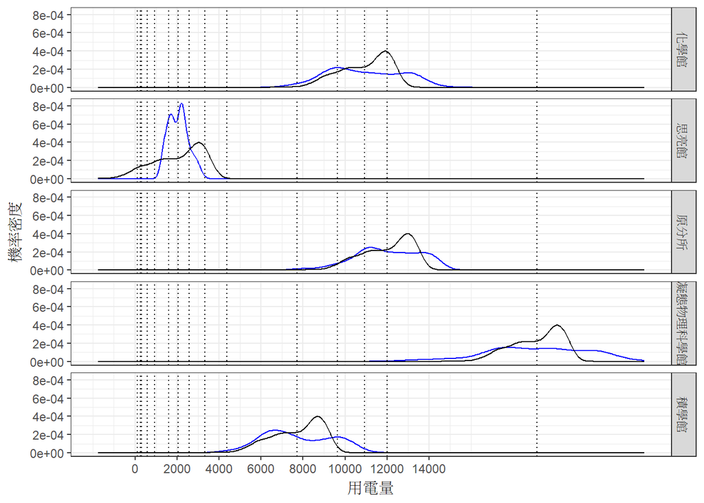

```r
ggplot(data = fit_m2, aes(x = ele, group = building )) +
  stat_density(geom = 'path', position = 'identity', col = "blue") +
  stat_density(geom = 'path', position = 'identity', aes(x = fitted)) +
  geom_vline(xintercept = c(with(rawdata1, tapply(ele,building, mean))), linetype = 'dotted')+
  facet_grid(building ~ .) +
  scale_x_continuous(breaks = seq(0, 14000, by = 2000))+
  labs(x = '用電量', y = '機率密度')
```

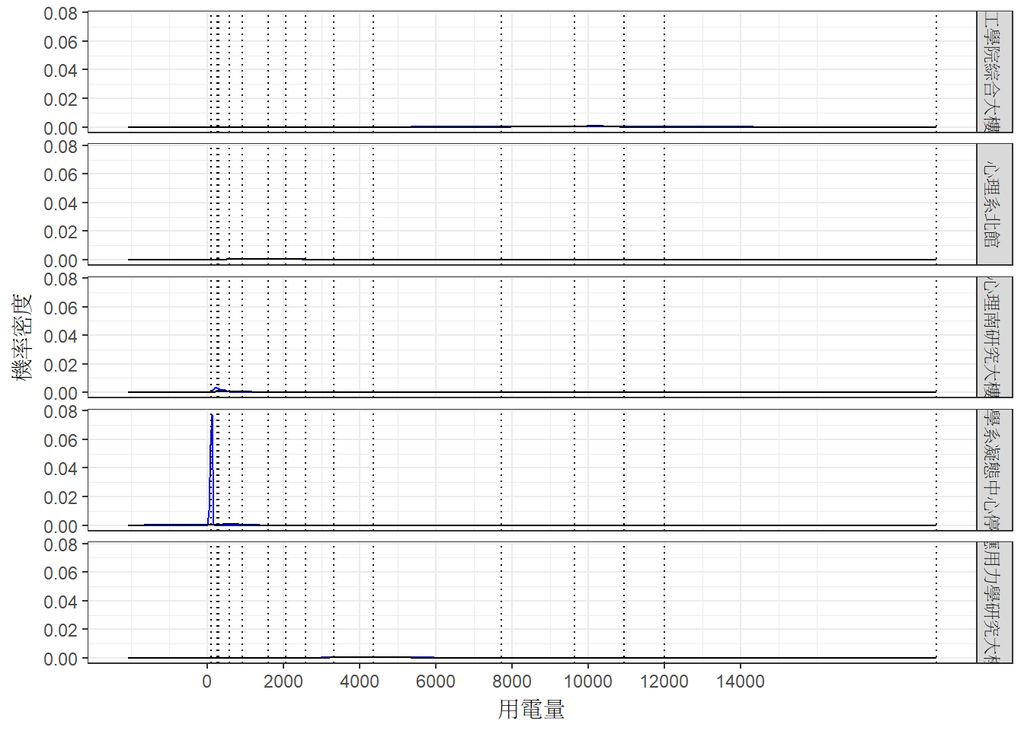

```r
ggplot(data = fit_m3, aes(x = ele, group = building )) +
  stat_density(geom = 'path', position = 'identity', col = "blue") +
  stat_density(geom = 'path', position = 'identity', aes(x = fitted)) +
  geom_vline(xintercept = c(with(rawdata1, tapply(ele,building, mean))), linetype = 'dotted')+
  facet_grid(building ~ .) +
  scale_x_continuous(breaks = seq(0, 14000, by = 2000))+
  labs(x = '用電量', y = '機率密度')
```

檢視常態假設

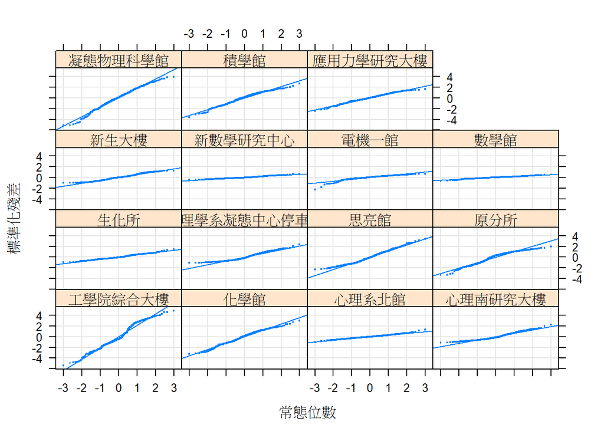

```r
require(lattice)
qqmath(~ scale(resid) | building, data = rbind(fit_m1, fit_m2, fit_m3), type = c('p', 'g', 'r'),
       xlab = '常態位數', ylab = '標準化殘差', layout = c(4, 4),
       pch = '.', cex = 2)
```

溫度對於用電量影響趨勢比較: 比較不同用電量相對於溫度會有怎麼樣的趨勢圖，而從比較中也可以看出誰的影響比較大。

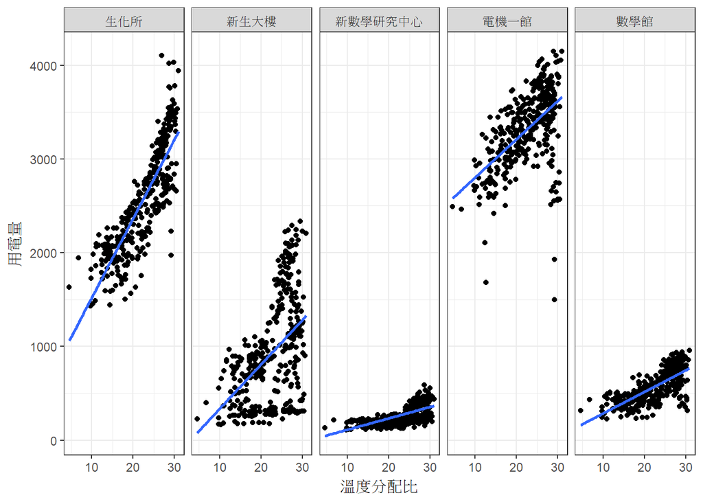

```r
ggplot(data = rd1,
       aes(group = building,
           y = ele, x = temp)) +
  geom_point() +
  stat_smooth(method = 'lm', se = F) +
  stat_smooth(aes(group = building,
                  y = ele, x = temp),
              method = 'lm', se = F) +
  facet_grid( . ~  building) +
  labs(x = '溫度分配比', y = '用電量')
```

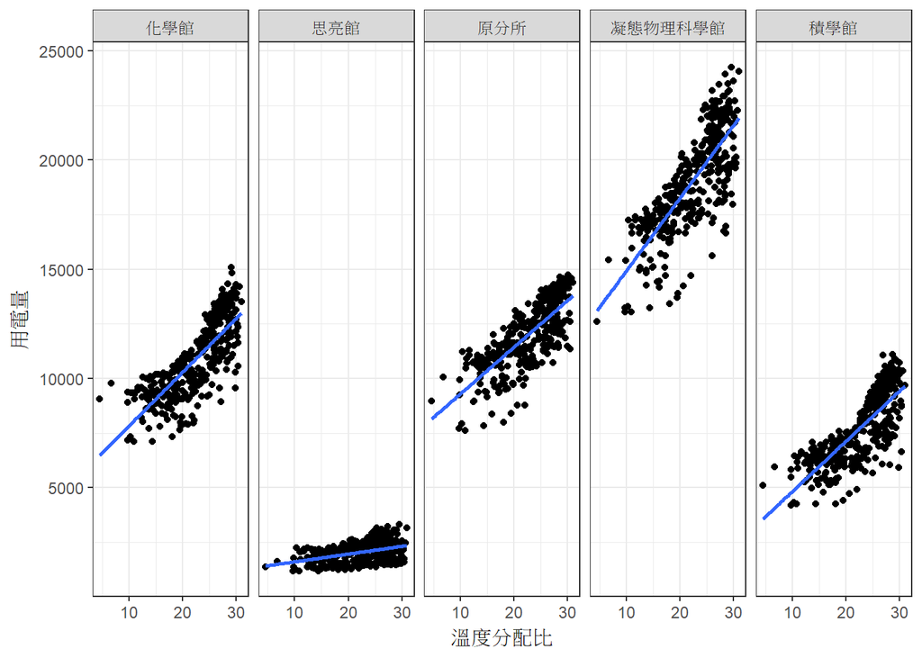

```r
ggplot(data = rd2,
       aes(group = building,
           y = ele, x = temp)) +
  geom_point() +
  stat_smooth(method = 'lm', se = F) +
  stat_smooth(aes(group = building,
                  y = ele, x = temp),
              method = 'lm', se = F) +
  facet_grid( . ~  building) +
  labs(x = '溫度分配比', y = '用電量')
```

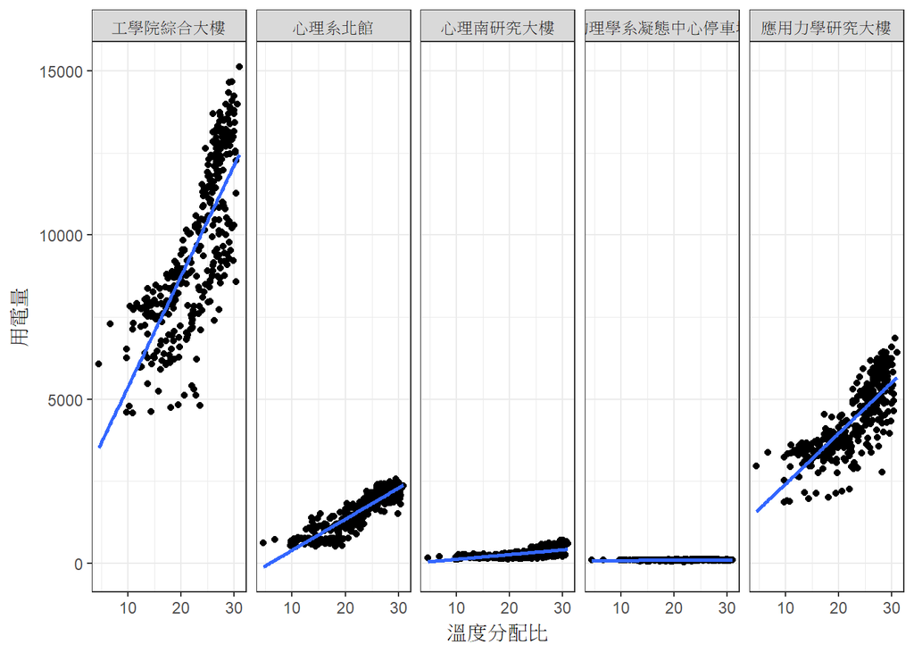

```r
ggplot(data = rd3,
       aes(group = building,
           y = ele, x = temp)) +
  geom_point() +
  stat_smooth(method = 'lm', se = F) +
  stat_smooth(aes(group = building,
                  y = ele, x = temp),
              method = 'lm', se = F) +
  facet_grid( . ~  building) +
  labs(x = '溫度分配比', y = '用電量')
```

上述圖片的分別放大圖，不過要注意座標軸不一樣。

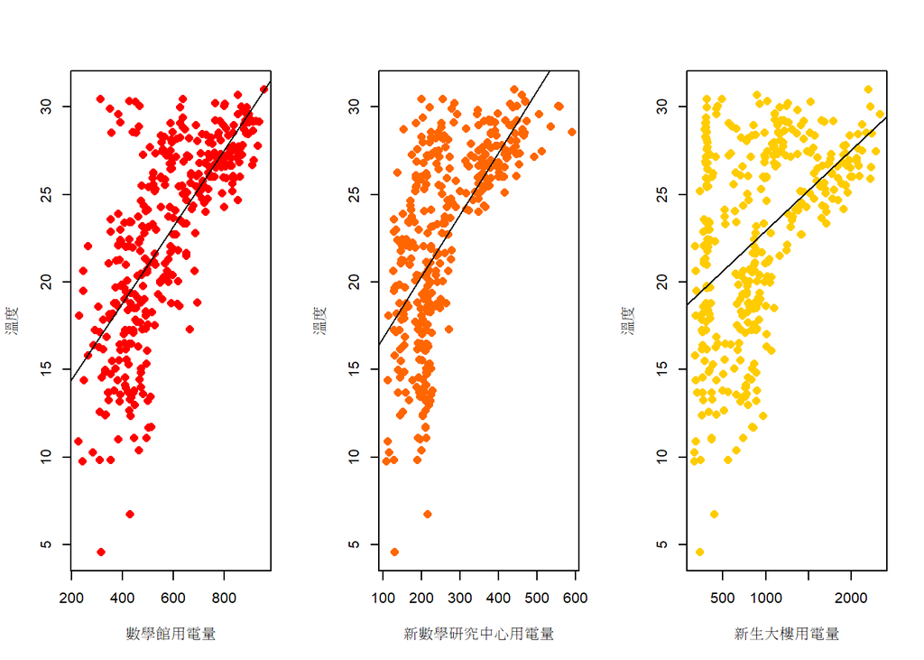

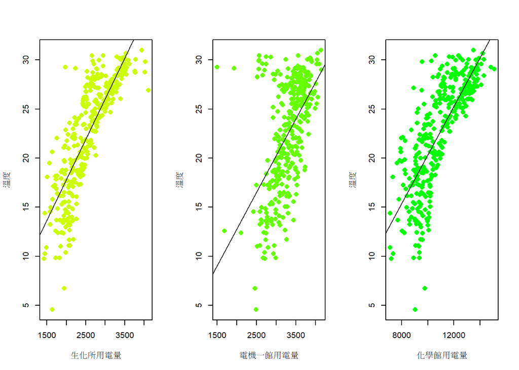

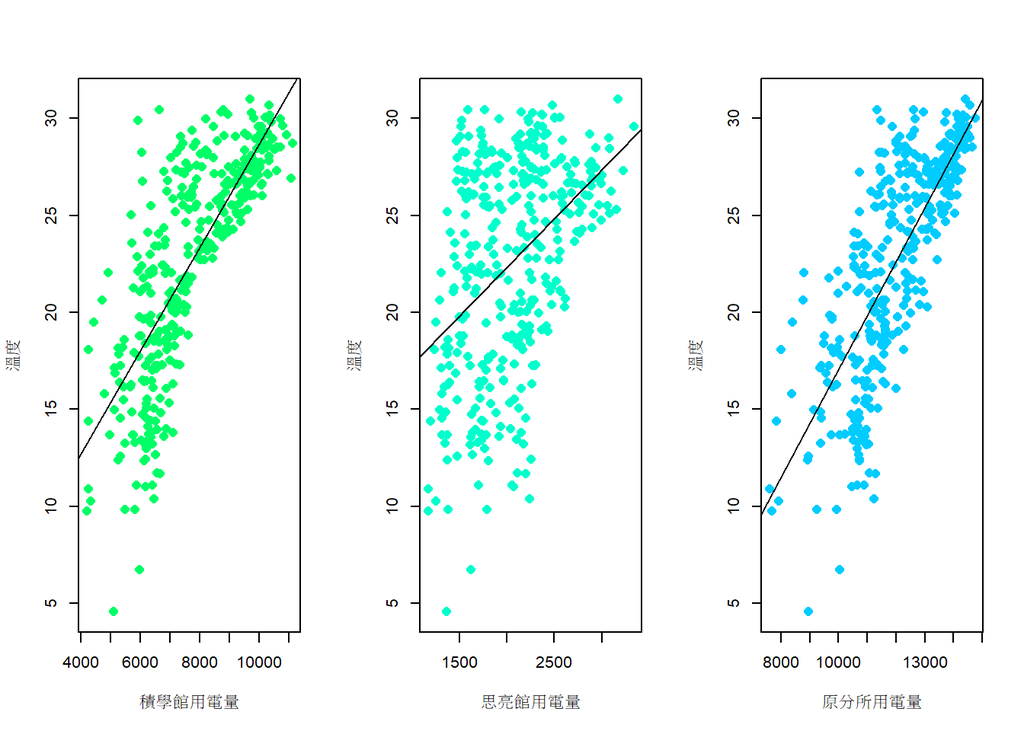

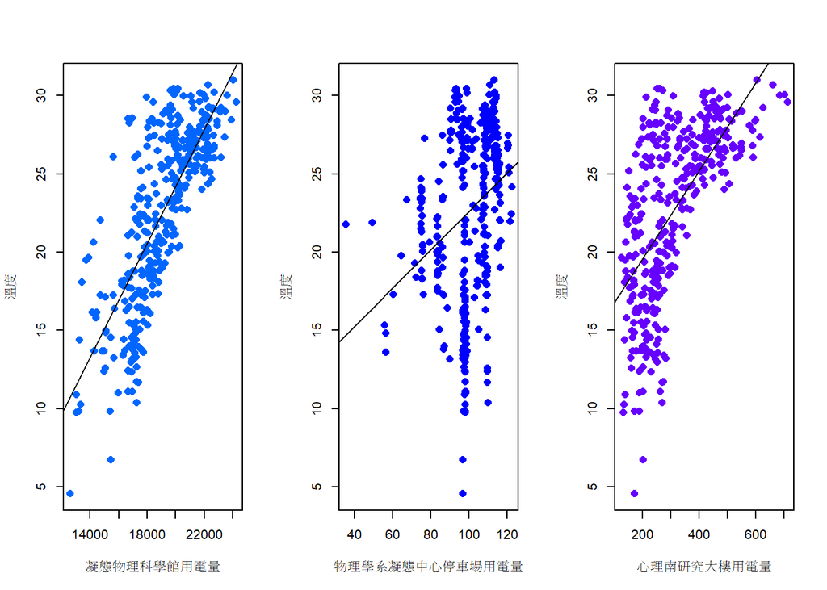

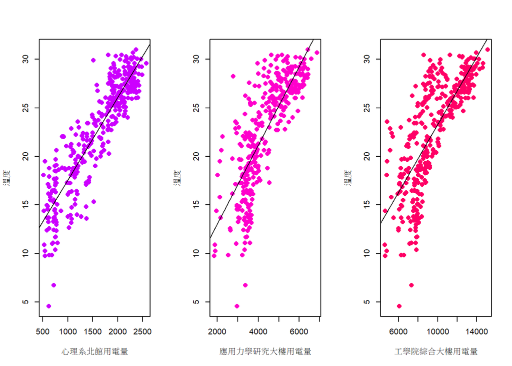

```r
colnames(rawdata) <- 1:dim(rawdata)[2]
lin <- function(x) {
  lm( rawdata$`17`~x)
}
lnco <- apply(rawdata[,2:16], 2, lin)
bname <- paste0(bunames[2:16],rep("用電量",15))
layout( matrix( 1:15 , 1, 3, byrow = T ))
for(i in 1:15) {
  plot(rawdata[,-1][,i], rawdata$`17`, pch = 16, cex = 1.3, col = rainbow(15)[i],
  xlab = bname[i], ylab = "溫度")
  abline(lnco[[i]])
}
```

```r
ttest2 <- data.frame()
for (t in 1:15){
 ttest2[t,1] <- as.numeric(t.test(rawdata[,t+1], rawdata[,17])$p.value)
}
row.names(ttest2) <- bunames[2:16]
colnames(ttest2) <- c("p-value")
ttest2
```

```
##                              p-value
## 數學館                 8.404266e-189
## 新數學研究中心         1.636270e-152
## 新生大樓               2.001951e-104
## 生化所                 1.274998e-247
## 電機一館                0.000000e+00
## 化學館                 3.025820e-295
## 積學館                 7.278227e-253
## 思亮館                 3.272638e-241
## 原分所                  0.000000e+00
## 凝態物理科學館          0.000000e+00
## 物理學系凝態中心停車場  0.000000e+00
## 心理南研究大樓         7.888544e-148
## 心理系北館             3.056637e-170
## 應用力學研究大樓       3.283728e-228
## 工學院綜合大樓         1.689035e-224
```

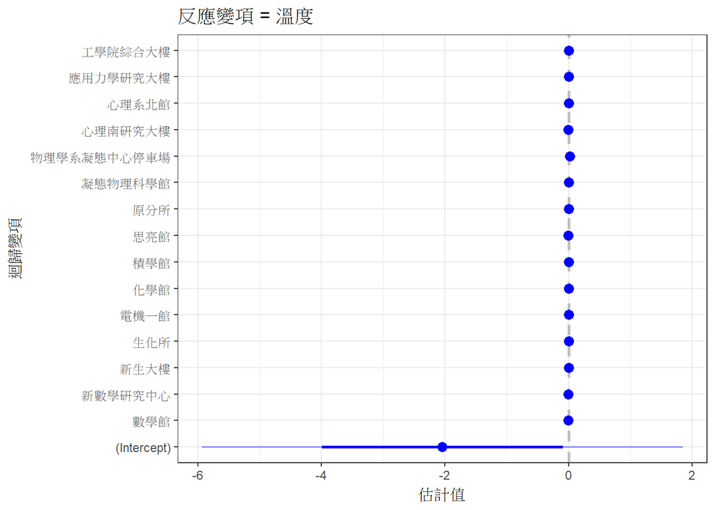

```r
# 每棟大樓電量變動皆為獨立
colnames(rawdata) <- bunames
require(coefplot)
result2 = lm( 溫度~數學館+新數學研究中心+新生大樓+生化所+電機一館+化學館+積學館+思亮館+原分所+凝態物理科學館+物理學系凝態中心停車場+心理南研究大樓+心理系北館+應用力學研究大樓+工學院綜合大樓, rawdata)
coefplot(result2, xlab = '估計值', ylab = '迴歸變項',
         title = '反應變項 = 溫度')
```

結論:

由上述的圖片中可以知道溫度幾乎會對大樓的用電量有相當程度的影響，而目前的影響推斷為冷氣使用，但是也可以從結果中得到影響的程度，這當中在一般的教學大樓中本來就是屬於較多人使用的情況，而用電量當然也會根據使用人的習慣而改變，而當中有幾個地方就沒有這麼容易受到溫度的影響，最明顯的例子為思亮館、凝態停車場等，這些地點目前推斷可能因為不是長時間持續被人使用，因此用電量都是基本輸出，並不會因為其他原因而有大量起伏，停車場就是一個典型的例子，大部分的人不會一天持續8、9小時都待在停車場，然而凝態和心理系南館的低起伏可能還要再深入研究探討。

另外比較另我覺得很意外的是凝態的物理館，對於製作實驗的大樓通常裡面就要有一些基本的條件，可能是溫度控制或是濕度控制等其他因素，所以冷氣機本上都會開著，但是從圖片上可以看到這棟大樓受到溫度的影響程度是相當的高，尤其比較這張圖的座標軸和其他圖的座標軸更可以感受到他變動的幅度，而前面也有提到由於冷氣一般都會持續開著，但是溫度還是受ˋ大很大的變動趨勢，目前的推論為這棟大樓可能有其他機器很受到溫度的影響，但目前不得而知，當然也有可能我假設錯誤，這棟樓和別的大樓一樣只是夏天冷氣開得特別勤快，不過倘若是如此的話我們也可以去探討為何同樣是開冷氣，這棟大樓因溫度所造成的消耗比其他棟大樓因溫度所造成的消耗有如此大的差距。

未來目的：

這裡已經使用溫度作為一個變數作為初步的比較，當然有發現到某些大樓會因這些變數而受到影響某些不會，那未來就是再去針對那些不受溫度影響的大樓找出不同的變數，看看他們到底會受到那些變數的影響，而這裡也可以看看前面那些電量的分布圖來找尋一些更特殊的現象進行分析，例如積學館也可以看出他受到溫度有一定的影響，但是在用電量機率密度那張上面可以看到她分得很散，他不同的用電量數值都有一定的機率發生。

而另外的問題為我們這組可能可以只去比較同類型的大樓，比如說都是教學型大樓或是都是做研究的大樓，這樣可以減少更多的偏差，因為放在一起比較的話會因為兩者太多變數是獨立的，而放在一起的話結果卻比較不出一些特別的現象。